# RNA-seq analysis

Sudarshan Chari

9/8/2019

This R Markdown document contains a walk-through for analyzing pooled (single-end) RNA-seq performed using *D.melanogaster* histone overexpression mutant caused by a knockdown of *Slbp* (Stem loop binding protein) gene and corresponding wild-type/ control. Raw transcript count data obtained by mapping to a reference transcriptome using Salmon (slurm/bash scripts calling the relevant functions to preprocess and map are in another repository).

“Desktop/RNAseq_output/” has been used as a local directory for this project, but that can be changed to any desired local or cloud based directory.

```r
# Libraries for RNA-seq count data analysis
library(tximport)
library(DESeq2)
library(apeglm)
library(vsn)
library(sva)
library(magrittr)
library(matrixStats)
library(metaRNASeq)

# Libraries for data handling and visualization
library(ggplot2)
library(dplyr)
library(pheatmap)
library(RColorBrewer)
library(genefilter)
library(dendsort)
library(reshape2)

#Libraries for database and GO analysis
library(goseq)
library(GO.db)
library(TxDb.Dmelanogaster.UCSC.dm6.ensGene)
library(org.Dm.eg.db)
```

Loading Gene annotation datasets transcript to geneID to gene name mappings, downloaded from flybase

```r
ttg.slbp <- read.table ("~/Desktop/RNAseq_output/Abo_Wt_StagedNC_flybase_transcriptome/scripts_samples_ttg/flybase_transcript_to_gene.txt", h=T)
head(ttg.slbp)
```

```
##          txId                Gene
## 1 FBtr0081624 dmel_7SLRNA:CR32864
## 2 FBtr0100521              dmel_a
## 3 FBtr0071764              dmel_a
## 4 FBtr0342981              dmel_a
## 5 FBtr0071763              dmel_a
## 6 FBtr0083388          dmel_abd-A
```

```r
fbgn.gene.conv <- read.table ("~/Desktop/RNAseq_output/Abo_Wt_StagedNC_flybase_transcriptome/scripts_samples_ttg/flybase_fbgn_to_gene.tsv", h=T)
head(fbgn.gene.conv)
```

```
##        geneId         Gene
## 1 FBgn0262029       dmel_d
## 2 FBgn0052532 dmel_CG32532
## 3 FBgn0023536  dmel_CG3156
## 4 FBgn0029718  dmel_mRpL30
## 5 FBgn0031101  dmel_CG1631
## 6 FBgn0030952 dmel_CG12609
```

## Differential Gene expression analysis

### Exploratory Analysis

```r
# Reading in the sample information file
sample.slbp.all <- read.csv("~/Desktop/RNAseq_output/Abo_Wt_StagedNC_flybase_transcriptome/data/SLBP/main/salmon_data_slbp_main_pilot_inc/samples_slbp_wt_main_pilot_inc.csv", h=T)
str(sample.slbp.all)
```

```
## 'data.frame':    28 obs. of  7 variables:
##  $ Sample       : Factor w/ 28 levels "SLBP_NC0_Pre9_R1_B2",..: 1 2 3 4 5 6 7 8 9 10 ...
##  $ Genotype     : Factor w/ 2 levels "SLBP","WT": 1 1 1 1 1 1 1 1 1 1 ...
##  $ Cycle        : Factor w/ 5 levels "NC0_Pre9","NC13",..: 1 1 1 1 1 2 2 2 2 2 ...
##  $ Replicate    : Factor w/ 6 levels "R1","R2","R3",..: 1 2 3 4 5 1 1 2 2 3 ...
##  $ Gen_Rep      : Factor w/ 25 levels "SLBP_NC0_Pre9_R1",..: 1 2 3 4 5 6 6 7 7 8 ...
##  $ Gen_Rep_Batch: Factor w/ 28 levels "SLBP_NC0_Pre9_R1_B2",..: 1 2 3 4 5 6 7 8 9 10 ...
##  $ Gen_Cyc      : Factor w/ 5 levels "SLBP_NC0_Pre9",..: 1 1 1 1 1 2 2 2 2 2 ...
```

```r
head(sample.slbp.all)
```

```
##                Sample Genotype    Cycle Replicate          Gen_Rep
## 1 SLBP_NC0_Pre9_R1_B2     SLBP NC0_Pre9        R1 SLBP_NC0_Pre9_R1
## 2 SLBP_NC0_Pre9_R2_B2     SLBP NC0_Pre9        R2 SLBP_NC0_Pre9_R2
## 3 SLBP_NC0_Pre9_R3_B2     SLBP NC0_Pre9        R3 SLBP_NC0_Pre9_R3
## 4 SLBP_NC0_Pre9_R4_B2     SLBP NC0_Pre9        R4 SLBP_NC0_Pre9_R4
## 5 SLBP_NC0_Pre9_R5_B2     SLBP NC0_Pre9        R5 SLBP_NC0_Pre9_R5
## 6     SLBP_NC13_R1_B1     SLBP     NC13        R1     SLBP_NC13_R1
##         Gen_Rep_Batch       Gen_Cyc
## 1 SLBP_NC0_Pre9_R1_B2 SLBP_NC0_Pre9
## 2 SLBP_NC0_Pre9_R2_B2 SLBP_NC0_Pre9
## 3 SLBP_NC0_Pre9_R3_B2 SLBP_NC0_Pre9
## 4 SLBP_NC0_Pre9_R4_B2 SLBP_NC0_Pre9
## 5 SLBP_NC0_Pre9_R5_B2 SLBP_NC0_Pre9
## 6     SLBP_NC13_R1_B1     SLBP_NC13
```

```r
levels(sample.slbp.all$Gen_Cyc)
```

```
## [1] "SLBP_NC0_Pre9" "SLBP_NC13"     "WT_NC0_Pre9"   "WT_NC13"
## [5] "WT_NC14"
```

```r
sample.slbp.all$Gen_Cyc <- relevel(sample.slbp.all$Gen_Cyc, ref="WT_NC0_Pre9")
# Ordering the dataset such that WT_NC0_Pre9
# i.e. the most initial developmental stages is the reference for all comparisons

# Reading in the raw count matrix files and coverting it into a DESeq object
files.slbp.all <- file.path("~/Desktop/RNAseq_output/Abo_Wt_StagedNC_flybase_transcriptome/data/SLBP/main/salmon_data_slbp_main_pilot_inc", sample.slbp.all$Sample, "quant.sf")
names(files.slbp.all) <- paste0("Sample", 1:28)
all(file.exists(files.slbp.all))
```

```
## [1] TRUE
```

```r
txi.slbp.all <- tximport(files.slbp.all, type = "salmon", tx2gene = ttg.slbp)
```

```
## reading in files with read_tsv
```

```
## 1 2 3 4 5 6 7 8 9 10 11 12 13 14 15 16 17 18 19 20 21 22 23 24 25 26 27 28
## summarizing abundance
## summarizing counts
## summarizing length
```

```r
names(txi.slbp.all)
```

```
## [1] "abundance"           "counts"              "length"
## [4] "countsFromAbundance"
```

```r
rownames(sample.slbp.all) <- colnames(txi.slbp.all$counts)
ddsTxi.slbp.all <- DESeqDataSetFromTximport(txi.slbp.all, colData = sample.slbp.all, design = ~ Gen_Cyc)
```

```
## using counts and average transcript lengths from tximport
```

```r
# The design here is Gen_Cyc == Genotype*Cycle == Genotype + Cycle + Genotype:Cycle
# main and interaction effects of Genotype and Cell cycle
```

There are a couple of other manipulations that can be performed before performing the actual analysis  
- The same libraries were sequenced on multiple lanes. These form technical replicates and can be combined into the appropriate biological replicate by summing the counts, using the `collapseReplicates()` function  
- The genes that have not received any reads or say below a threshold level of counts can be eliminated before analysis

```r
# Collapsing the technical replicates
ddsColl.slbp.all <- collapseReplicates (ddsTxi.slbp.all, ddsTxi.slbp.all$Gen_Rep, ddsTxi.slbp.all$Gen_Rep_Batch)
colData(ddsColl.slbp.all)
```

[output not shown]

```r
# Retaining a gene if it has over 1 reads in 2 or more samples
# This is a very permissive threshold to eliminate any unintentional filtration bias
ddsColl.slbp.all
```

```
## class: DESeqDataSet
## dim: 13728 25
## metadata(1): version
## assays(2): counts avgTxLength
## rownames(13728): dmel_1-Dec dmel_1-Sep ... dmel_zye dmel_Zyx
## rowData names(0):
## colnames(25): SLBP_NC0_Pre9_R1 SLBP_NC0_Pre9_R2 ... WT_NC14_R4
##   WT_NC14_R5
## colData names(8): Sample Genotype ... Gen_Cyc runsCollapsed
```

```r
keep.slbp.all <- rowSums(counts(ddsColl.slbp.all) >1) >= 2
ddsColl.keep.slbp.all <- ddsColl.slbp.all[keep.slbp.all,]
ddsColl.keep.slbp.all # 10860 genes
```

```
## class: DESeqDataSet
## dim: 10860 25
## metadata(1): version
## assays(2): counts avgTxLength
## rownames(10860): dmel_1-Dec dmel_1-Sep ... dmel_zye dmel_Zyx
## rowData names(0):
## colnames(25): SLBP_NC0_Pre9_R1 SLBP_NC0_Pre9_R2 ... WT_NC14_R4
##   WT_NC14_R5
## colData names(8): Sample Genotype ... Gen_Cyc runsCollapsed
```

Perform the DESeq2 normalization followed by  
- regularized log transformation  
- similarity between samples based on Euclidean distance  
- principal components analysis (PCA)

```r
deseq.slbp.all <- DESeq(ddsColl.keep.slbp.all)
```

```
## using 'avgTxLength' from assays(dds), correcting for library size
```

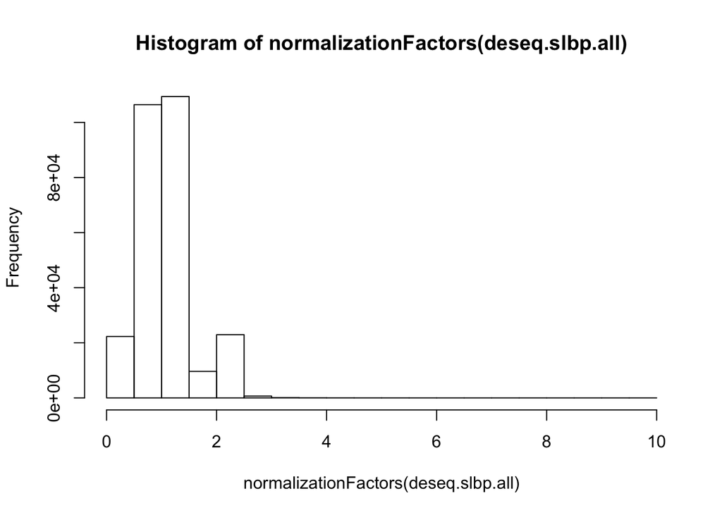

```r
hist(normalizationFactors(deseq.slbp.all))
```

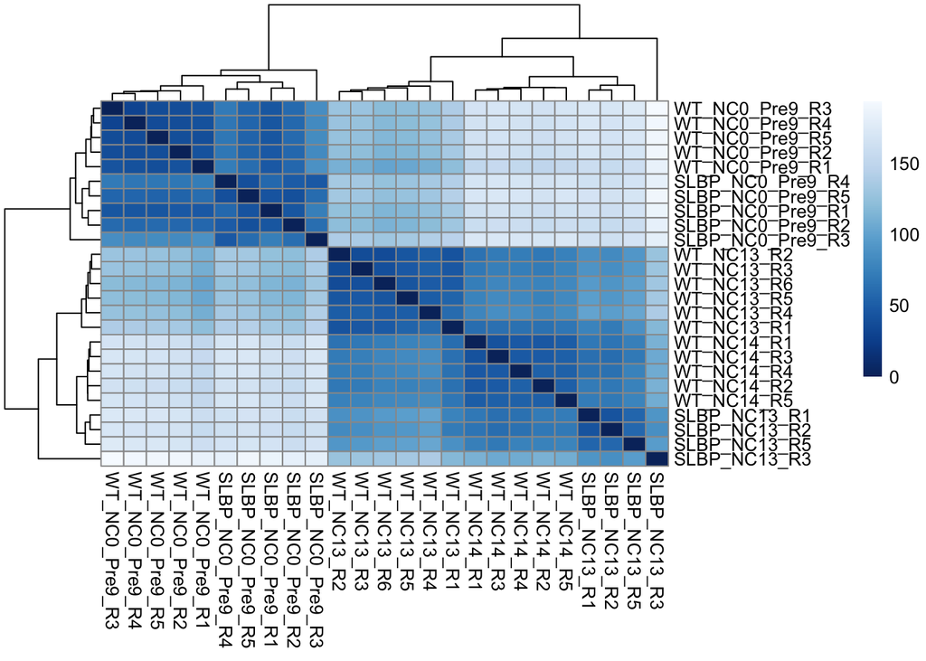

```r
# histogram of normalization factors typically distributed with a mean/ median ~1.0
rld.slbp.all <- rlog(deseq.slbp.all, blind=T)

sampleDists.slbp.all <- dist(t(assay(rld.slbp.all)))
hm.mat.slbp.all <- as.matrix( sampleDists.slbp.all)
colors <- colorRampPalette( rev(brewer.pal(9, "Blues")) )(255)

# heirarchical clustering of the sample distances
hm.col.clust.slbp.all <- hclust(dist(t(hm.mat.slbp.all)))
sort.hclust <- function(...) as.hclust(dendsort(as.dendrogram(...)))
hm.col.clust.slbp.all <- sort.hclust(hclust(dist(t(hm.mat.slbp.all))))
hm.row.clust.slbp.all <- sort.hclust(hclust(dist(hm.mat.slbp.all)))

#visualizing the clustered sample distances
pheatmap(
  mat             = hm.mat.slbp.all,
  color                 = colors,
  cluster_cols    = hm.col.clust.slbp.all,
  cluster_rows    = hm.row.clust.slbp.all,
  show_rownames   = T
)
```

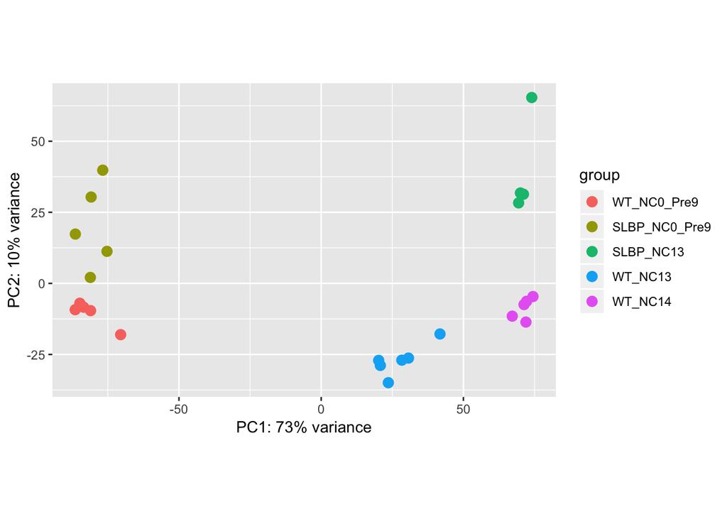

```r
#plotting PCA
plotPCA(rld.slbp.all, intgroup=c("Gen_Cyc"),ntop=5000)
```

The Euclidean distance based similarity of expression data for WT and Slbp embryos at different timepoints demonstrate that replicates are more similar to each other than they are to other genotypes and/ or timepoints

Principal Components Analysis of Slbp and WT expression data also shows that global transcriptomic profile is shifted in Slbp NC13 as compared WT NC13 and is more similar to WT NC14 indicating that the onset of transcription is advanced in Slbp embryos